# Deaths - EPI2 Scenarios

Pragati Prasad

2022-04-13

## Mean, Cumulative with 95% CI, and Averted per 100K

### Scenario HP13

Base Scenario: R0 of 1.7 and “2009-like” severity multiplied by 2 for all age groups except 65+, which remains the same as 2009

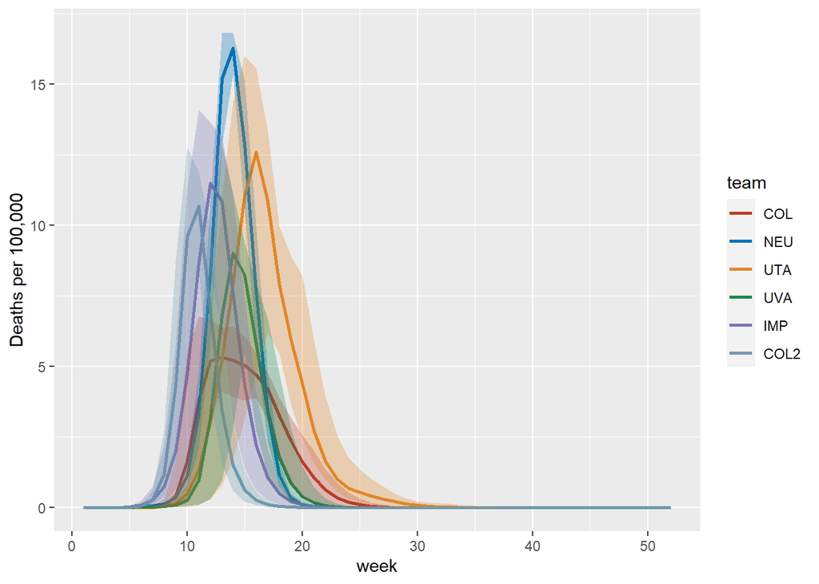

```r
library(ggsci)
library(reshape)
library(dplyr)
library(gridExtra)
library(ggplot2)
library(egg)
library(plyr)
library(tidyr)
library(knitr)
library(kableExtra)

path <- "../../model-forecasts/"

team.folder <- c("Columbia/COL/EPI2/", "Northeastern/EPI2/", "UTAustin/", "UVirginia/", "Imperial/", "Columbia/COL2/EPI2/")
team.abbrev <- c("COL", "NEU", "UTA", "UVA", "IMP", "COL2")
file.types <-c("SymIllness", "Hosp", "Deaths", "AntiviralTX")
scn = "HP13_"
read_overall_mean <- function(scn){

  cols <- c("sm.mean", "sm.perc2p5", "sm.perc97p5")

  s <- read.csv(paste0(path,team.folder[1],scn,file.types[3],"_",team.abbrev[1],".csv"))
  death <- data.frame(c(s[which(s$Agegroup == "Overall" &
                                       s$Bin %in% cols),],
                             `team` = team.abbrev[1]))

  for(i in 2:6){

    if(i == 4){
      scn = gsub("HP", "HP_", scn)
    }
    if(i == 5){
      scn = gsub("_", "", scn)
    }
    if(i == 6){
      scn = paste0(scn, "_")
    }
    f = paste0(path,team.folder[i],scn,file.types[3],"_",team.abbrev[i],".csv")
    if(i == 5){
      f =  paste0(path,team.folder[i],scn,"Death",team.abbrev[i],".csv")
    }
    if(file.exists(f)){
      s <- read.csv(f)
      if(ncol(s) > 59){
        s <- s[-1]
      }
      if(i == 4){
        s <- s[which(s$Location == "US National"),]
      }
      death <- rbind.fill(death,
                               data.frame(c(s[which(s$Agegroup == "Overall" &
                                                      s$Bin %in% cols),],`team` = team.abbrev[i])))
    }

  }
  weeks <- paste0("Week",1:52)
  death$Cml[which(is.na(death$Cml))] <- death$cml[which(is.na(death$Cml))]
  cml <<- death[c("Cml", "team", "Bin")]

  long <- gather(death, week, illnesses, weeks, factor_key=TRUE)
  long$week <- as.integer(gsub("Week", "", long$week))

  cols <- c("Bin", "team", "week", "illnesses")
  long <- long[cols]
  long_wide <- spread(long, Bin, illnesses)

  return(long_wide)
}

long_HP13 <- read_overall_mean(scn = "HP13_")

ggplot(data = long_HP13, aes(x = week, y = sm.mean, group = team)) +
  geom_line(aes(color = team), lwd = 1.0) +
  geom_ribbon(aes(ymin = sm.perc2p5, ymax = sm.perc97p5, fill = team), alpha = 0.3,
              show.legend = FALSE)+
  ylab("Deaths per 100,000") +
  scale_color_nejm() +
  scale_fill_nejm()
```

```r
table <- cml[which(cml$Bin == "sm.mean"),]
table <- table[,-3]

table$lower <-  cml$Cml[which(cml$Bin == "sm.perc2p5")]
table$upper <-  cml$Cml[which(cml$Bin == "sm.perc97p5")]
table$Team <- table$team
table$`Cum. Deaths per 100K` <- table$Cml
table$`95% CI` <- paste0("(", round(table$lower, 2), ", ", round(table$upper, 2), ")")

rownames(table) <- NULL

knitr::kable(table[5:7], digits = 2, caption = "HP13, No Intervention", align=rep('c', 3)) %>%
  kable_styling(bootstrap_options = c("striped", "hover"))
```

HP13, No Intervention

| Team | Cum. Deaths per 100K | 95% CI |
| --- | --- | --- |
| COL | 45.39 | (38.56, 51.99) |
| NEU | 70.50 | (70.41, 70.77) |
| UTA | 79.01 | (59.75, 93.2) |
| UVA | 41.34 | (34.49, 47.31) |
| IMP | 55.10 | (50.83, 60.88) |
| COL2 | 39.15 | (37.37, 41.07) |

```r
table1 <- table

team.folder <- c("Columbia/COL/EPI2/", "Northeastern/EPI2/", "UTAustin/", "UVirginia/", "Imperial/", "Columbia/COL2/EPI2/")

#Bar chart for age stratification
read_ages <- function(scn){

  cols <- c("sm.mean", "sm.perc2p5", "sm.perc97p5")

  s <- read.csv(paste0(path,team.folder[1],scn,file.types[3],"_",team.abbrev[1],".csv"))
  death <- data.frame(c(s[which(s$Bin %in% cols),],
                             `team` = team.abbrev[1]))

  for(i in 2:6){

    if(i == 4){
      scn = gsub("HP", "HP_", scn)
    }
    if(i == 5){
      scn = gsub("_", "", scn)
    }
    if(i == 6){
      scn = paste0(scn, "_")
    }
    f = paste0(path,team.folder[i],scn,file.types[3],"_",team.abbrev[i],".csv")
    if(i == 5){
      f =  paste0(path,team.folder[i],scn,"Death",team.abbrev[i],".csv")
    }
    if(file.exists(f)){
      s <- read.csv(f)
      if(ncol(s) > 59){
        s <- s[-1]
      }
      if(i == 4){
        s <- s[which(s$Location == "US National"),]
      }
      death <- rbind.fill(death,
                               data.frame(c(s[which(s$Bin %in% cols),],`team` = team.abbrev[i])))
    }

  }
  weeks <- paste0("Week",1:52)
  death$Cml[which(is.na(death$Cml))] <- death$cml[which(is.na(death$Cml))]
  cml <- death[c("Cml", "team", "Bin", "Agegroup")]
  cml$Agegroup <- sub("yr", "years", cml$Agegroup)
  cml$Agegroup <- factor(x = cml$Agegroup, levels = c("Overall", "0-4 years", "5-17 years", "18-49 years", "50-64 years", "65+ years"))

  return(cml)
}

ages_1 <- read_ages(scn = "HP13_")
png("age_supp2b.png",width = 850, height=500)
ggplot(ages_1[which(ages_1$Agegroup != "Overall"),], aes(fill=Agegroup, y=Cml, x=team)) +
  geom_bar(position="fill", stat="identity") +
  ylab("Percent")+
  scale_fill_d3()
dev.off()
```

```r
scenario = "HP13_"
averted_age <- data.frame(scenario = scenario,
                          team = ages_1$team[which(ages_1$Bin == "sm.mean")],
                          agegroup = ages_1$Agegroup[which(ages_1$Bin == "sm.mean")],
                          cml = ages_1$Cml[which(ages_1$Bin == "sm.mean")],
                          lower = ages_1$Cml[which(ages_1$Bin == "sm.perc2p5")],
                          upper = ages_1$Cml[which(ages_1$Bin == "sm.perc97p5")])
write.csv(averted_age, "Deaths_EPI2_HP13.csv")
```

### HP14

VX1

“Early”: Vaccine available 100 days after September 1

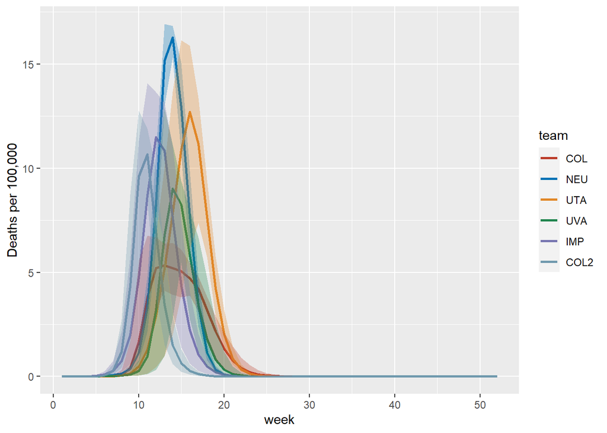

```r
scenario <- "HP14_"

long <- read_overall_mean(scn = scenario)

ggplot(data = long, aes(x = week, y = sm.mean, group = team)) +
  geom_line(aes(color = team), lwd = 1.0) +
  geom_ribbon(aes(ymin = sm.perc2p5, ymax = sm.perc97p5, fill = team), alpha = 0.3,
              show.legend = FALSE)+
  ylab("Deaths per 100,000") +
  scale_color_nejm() +
  scale_fill_nejm()
```

```r
table <- cml[which(cml$Bin == "sm.mean"),]
table <- table[,-3]

table$lower <-  cml$Cml[which(cml$Bin == "sm.perc2p5")]
table$upper <-  cml$Cml[which(cml$Bin == "sm.perc97p5")]
table$Team <- table$team
table$`Cum. Deaths per 100K` <- table$Cml
table$`95% CI` <- paste0("(", round(table$lower, 2), ", ", round(table$upper, 2), ")")

table$`Averted Deaths per 100K (HP13)` <- ifelse(table$Team %in% table1$Team, table1$`Cum. Deaths per 100K` - table$`Cum. Deaths per 100K`, NA)
table$`% Reduction in Burden (HP13)` <- ifelse(table$Team %in% table1$Team, 100 * (table1$`Cum. Deaths per 100K` - table$`Cum. Deaths per 100K`) / table1$`Cum. Deaths per 100K`, NA)

rownames(table) <- NULL

knitr::kable(table[5:9], digits = 2, caption = "HP14: Compared to HP13", align=rep('c', 4)) %>%
  kable_styling(bootstrap_options = c("striped", "hover"))
```

HP14: Compared to HP13

| Team | Cum. Deaths per 100K | 95% CI | Averted Deaths per 100K (HP13) | % Reduction in Burden (HP13) |
| --- | --- | --- | --- | --- |
| COL | 43.93 | (35.91, 51.31) | 1.46 | 3.21 |
| NEU | 70.47 | (70.38, 70.72) | 0.03 | 0.04 |
| UTA | 68.01 | (39.28, 87.65) | 11.00 | 13.92 |
| UVA | 41.13 | (33.46, 47.3) | 0.21 | 0.50 |
| IMP | 55.00 | (50.64, 60.78) | 0.10 | 0.19 |
| COL2 | 39.14 | (37.35, 41.05) | 0.01 | 0.03 |

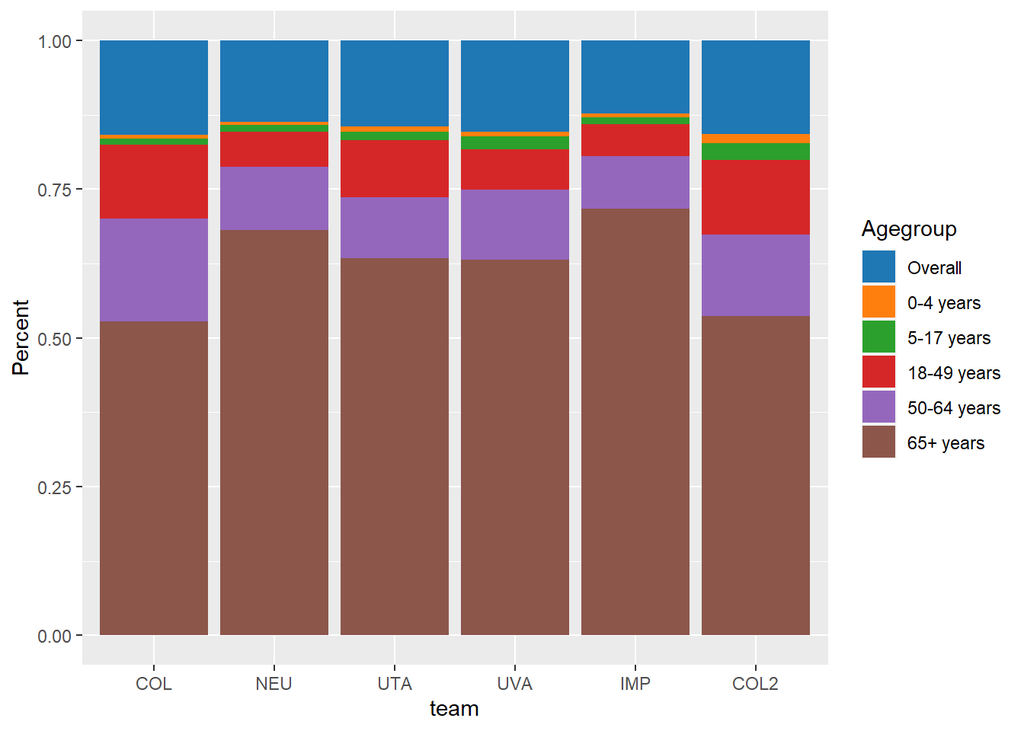

```r
ages <- read_ages(scn = scenario)
ggplot(ages, aes(fill=Agegroup, y=Cml, x=team)) +
  geom_bar(position="fill", stat="identity") +
  ylab("Percent")+
  scale_fill_d3()
```

```r
averted <- data.frame(scenario = rep(scenario, nrow(table)),
                                     team = table$Team,
                                     reduction = table$`% Reduction in Burden (HP13)`)
averted_age <- data.frame(scenario = scenario,
                          team = ages$team[which(ages$Bin == "sm.mean")],
                          agegroup = ages$Agegroup[which(ages$Bin == "sm.mean")],
                          reduction = 100*(ages_1$Cml[which(ages_1$Bin == "sm.mean")] -
                                       ages$Cml[which(ages$Bin == "sm.mean")]) /
                            ages_1$Cml[which(ages_1$Bin == "sm.mean")])
```

### HP15

VX2

“Normal”: Vaccine available 150 days after September 1

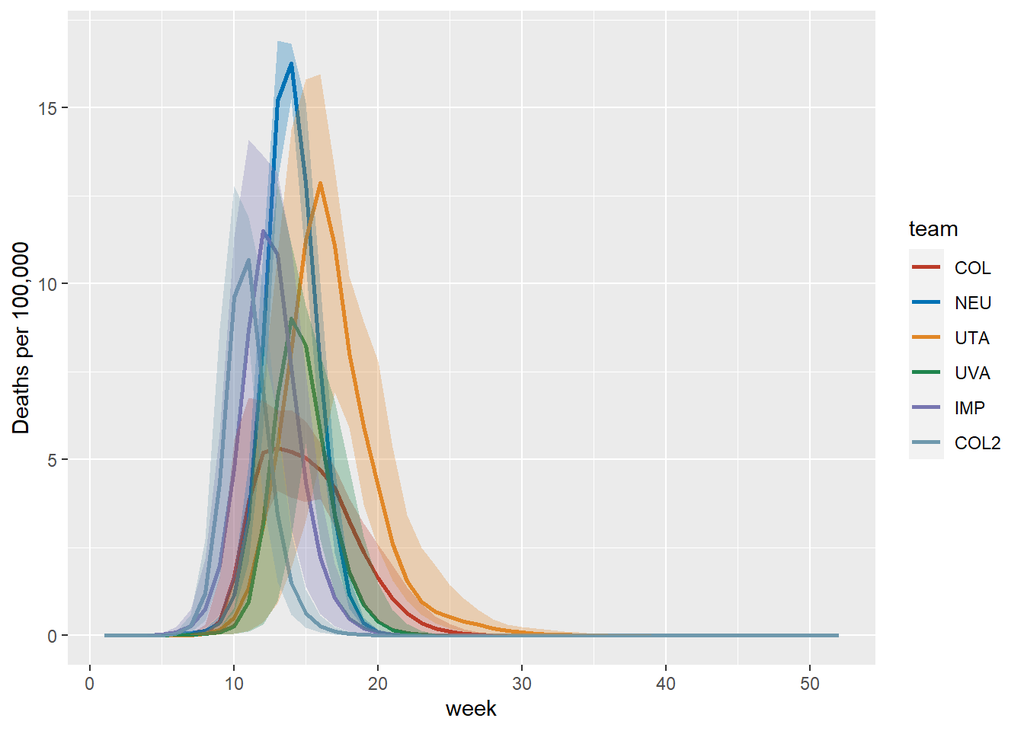

```r
scenario <- "HP15_"

long <- read_overall_mean(scn = scenario)

ggplot(data = long, aes(x = week, y = sm.mean, group = team)) +
  geom_line(aes(color = team), lwd = 1.0) +
  geom_ribbon(aes(ymin = sm.perc2p5, ymax = sm.perc97p5, fill = team), alpha = 0.3,
              show.legend = FALSE)+
  ylab("Deaths per 100,000") +
  scale_color_nejm() +
  scale_fill_nejm()
```

```r
table <- cml[which(cml$Bin == "sm.mean"),]
table <- table[,-3]

table$lower <-  cml$Cml[which(cml$Bin == "sm.perc2p5")]
table$upper <-  cml$Cml[which(cml$Bin == "sm.perc97p5")]
table$Team <- table$team
table$`Cum. Deaths per 100K` <- table$Cml
table$`95% CI` <- paste0("(", round(table$lower, 2), ", ", round(table$upper, 2), ")")

table$`Averted Deaths per 100K (HP13)` <- ifelse(table$Team %in% table1$Team, table1$`Cum. Deaths per 100K` - table$`Cum. Deaths per 100K`, NA)
table$`% Reduction in Burden (HP13)` <- ifelse(table$Team %in% table1$Team, 100 * (table1$`Cum. Deaths per 100K` - table$`Cum. Deaths per 100K`) / table1$`Cum. Deaths per 100K`, NA)

rownames(table) <- NULL

knitr::kable(table[5:9], digits = 2, caption = "HP15: Compared to HP13", align=rep('c', 4)) %>%
  kable_styling(bootstrap_options = c("striped", "hover"))
```

HP15: Compared to HP13

| Team | Cum. Deaths per 100K | 95% CI | Averted Deaths per 100K (HP13) | % Reduction in Burden (HP13) |
| --- | --- | --- | --- | --- |
| COL | 45.39 | (38.56, 51.99) | 0.00 | 0.00 |
| NEU | 70.49 | (70.41, 70.77) | 0.00 | 0.00 |
| UTA | 79.75 | (61.6, 93.43) | -0.74 | -0.93 |
| UVA | 41.34 | (34.49, 47.31) | 0.00 | 0.00 |
| IMP | 55.00 | (50.64, 60.78) | 0.10 | 0.19 |
| COL2 | 39.15 | (37.37, 41.07) | 0.00 | 0.00 |

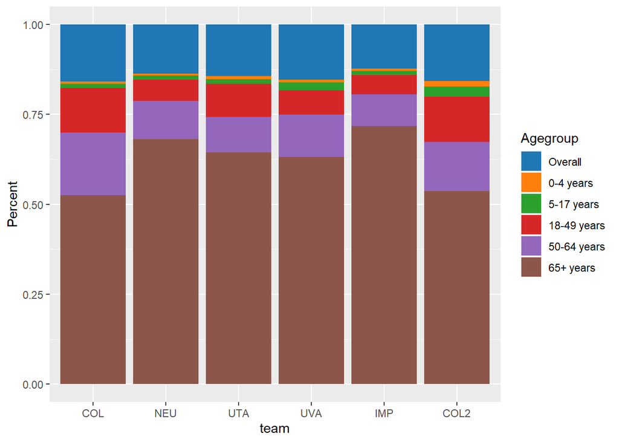

```r
ages <- read_ages(scn = scenario)
ggplot(ages, aes(fill=Agegroup, y=Cml, x=team)) +
  geom_bar(position="fill", stat="identity") +
  ylab("Percent")+
  scale_fill_d3()
```

```r
averted <- rbind(averted, data.frame(scenario = rep(scenario, nrow(table)),
                                     team = table$Team,
                                     reduction = table$`% Reduction in Burden (HP13)`))
averted_age <- rbind(averted_age,
                     data.frame(scenario = scenario,
                          team = ages$team[which(ages$Bin == "sm.mean")],
                          agegroup = ages$Agegroup[which(ages$Bin == "sm.mean")],
                          reduction = 100*(ages_1$Cml[which(ages_1$Bin == "sm.mean")] -
                                       ages$Cml[which(ages$Bin == "sm.mean")]) /
                            ages_1$Cml[which(ages_1$Bin == "sm.mean")]))
```

### HP16

SC1

Weekly Symptomatic Prevalence > 1% trigger, early (VX1) vaccine availability reopening

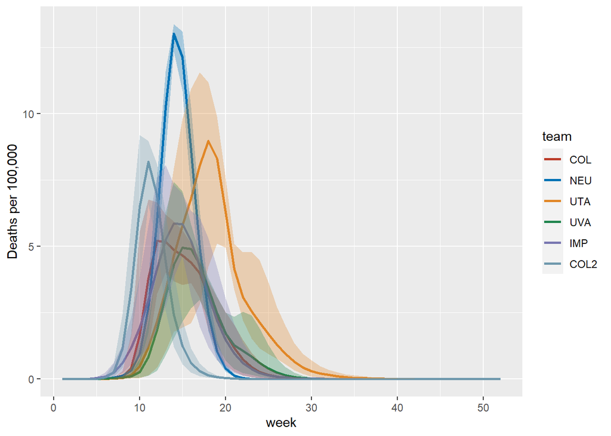

```r
scenario <- "HP16_"

long <- read_overall_mean(scn = scenario)

ggplot(data = long, aes(x = week, y = sm.mean, group = team, color = team)) +
  geom_line(aes(color = team), lwd = 1.0) +
  geom_ribbon(aes(ymin = sm.perc2p5, ymax = sm.perc97p5, fill = team),
              alpha = 0.3,
              linetype=0,
              show.legend = FALSE)+
  ylab("Deaths per 100,000") +
  scale_color_nejm() +
  scale_fill_nejm()
```

```r
table <- cml[which(cml$Bin == "sm.mean"),]
table <- table[,-3]

table$lower <-  cml$Cml[which(cml$Bin == "sm.perc2p5")]
table$upper <-  cml$Cml[which(cml$Bin == "sm.perc97p5")]
table$Team <- table$team
table$`Cum. Deaths per 100K` <- table$Cml
table$`95% CI` <- paste0("(", round(table$lower, 2), ", ", round(table$upper, 2), ")")

table$`Averted Deaths per 100K (HP13)` <- ifelse(table$Team %in% table1$Team, table1$`Cum. Deaths per 100K` - table$`Cum. Deaths per 100K`, NA)
table$`% Reduction in Burden (HP13)` <- ifelse(table$Team %in% table1$Team, 100 * (table1$`Cum. Deaths per 100K` - table$`Cum. Deaths per 100K`) / table1$`Cum. Deaths per 100K`, NA)

rownames(table) <- NULL

knitr::kable(table[5:9], digits = 2, caption = "HP16: Compared to HP13", align=rep('c', 4)) %>%
  kable_styling(bootstrap_options = c("striped", "hover"))
```

HP16: Compared to HP13

| Team | Cum. Deaths per 100K | 95% CI | Averted Deaths per 100K (HP13) | % Reduction in Burden (HP13) |
| --- | --- | --- | --- | --- |
| COL | 44.45 | (37.85, 51.04) | 0.94 | 2.07 |
| NEU | 63.14 | (63.07, 63.33) | 7.36 | 10.43 |
| UTA | 74.27 | (56.12, 88.35) | 4.74 | 6.00 |
| UVA | 37.14 | (31.52, 43.06) | 4.21 | 10.17 |
| IMP | 47.10 | (42.9, 52.13) | 8.00 | 14.52 |
| COL2 | 35.73 | (33.93, 37.69) | 3.42 | 8.74 |

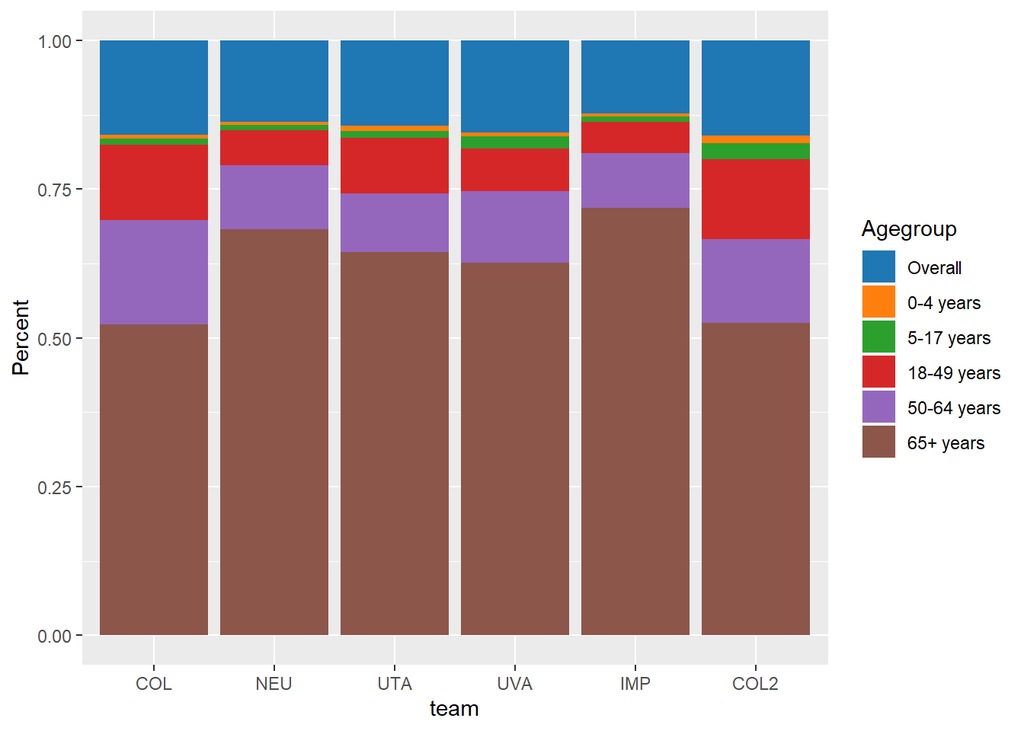

```r
ages <- read_ages(scn = scenario)
ggplot(ages, aes(fill=Agegroup, y=Cml, x=team)) +
  geom_bar(position="fill", stat="identity") +
  ylab("Percent")+
  scale_fill_d3()
```

```r
averted <- rbind(averted, data.frame(scenario = rep(scenario, nrow(table)),
                                     team = table$Team,
                                     reduction = table$`% Reduction in Burden (HP13)`))
averted_age <- rbind(averted_age,
                     data.frame(scenario = scenario,
                          team = ages$team[which(ages$Bin == "sm.mean")],
                          agegroup = ages$Agegroup[which(ages$Bin == "sm.mean")],
                          reduction = 100*(ages_1$Cml[which(ages_1$Bin == "sm.mean")] -
                                       ages$Cml[which(ages$Bin == "sm.mean")]) /
                            ages_1$Cml[which(ages_1$Bin == "sm.mean")]))
```

### HP17

SC2

Close on October 28, early (VX1) vaccine availability reopening

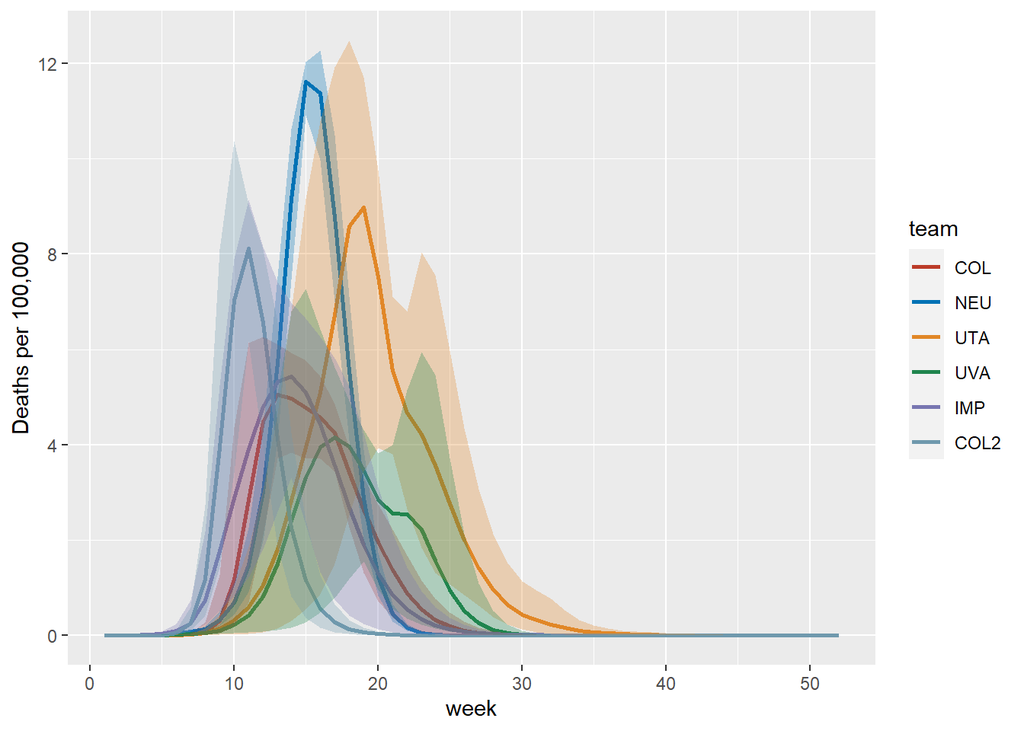

```r
scenario <- "HP17_"

long <- read_overall_mean(scn = scenario)

ggplot(data = long, aes(x = week, y = sm.mean, group = team)) +
  geom_line(aes(color = team), lwd = 1.0) +
  geom_ribbon(aes(ymin = sm.perc2p5, ymax = sm.perc97p5, fill = team), alpha = 0.3,
              show.legend = FALSE)+
  ylab("Deaths per 100,000") +
  scale_color_nejm() +
  scale_fill_nejm()
```

```r
table <- cml[which(cml$Bin == "sm.mean"),]
table <- table[,-3]

table$lower <-  cml$Cml[which(cml$Bin == "sm.perc2p5")]
table$upper <-  cml$Cml[which(cml$Bin == "sm.perc97p5")]
table$Team <- table$team
table$`Cum. Deaths per 100K` <- table$Cml
table$`95% CI` <- paste0("(", round(table$lower, 2), ", ", round(table$upper, 2), ")")

table$`Averted Deaths per 100K (HP13)` <- ifelse(table$Team %in% table1$Team, table1$`Cum. Deaths per 100K` - table$`Cum. Deaths per 100K`, NA)
table$`% Reduction in Burden (HP13)` <- ifelse(table$Team %in% table1$Team, 100 * (table1$`Cum. Deaths per 100K` - table$`Cum. Deaths per 100K`) / table1$`Cum. Deaths per 100K`, NA)

rownames(table) <- NULL

knitr::kable(table[5:9], digits = 2, caption = "HP17: Compared to HP13", align=rep('c', 4)) %>%
  kable_styling(bootstrap_options = c("striped", "hover"))
```

HP17: Compared to HP13

| Team | Cum. Deaths per 100K | 95% CI | Averted Deaths per 100K (HP13) | % Reduction in Burden (HP13) |
| --- | --- | --- | --- | --- |
| COL | 44.10 | (37.57, 50.66) | 1.29 | 2.83 |
| NEU | 62.77 | (62.75, 62.85) | 7.72 | 10.96 |
| UTA | 75.02 | (59.6, 90.71) | 3.99 | 5.05 |
| UVA | 38.23 | (33.76, 43.05) | 3.11 | 7.52 |
| IMP | 46.68 | (43.61, 51.84) | 8.42 | 15.27 |
| COL2 | 35.81 | (33.98, 37.8) | 3.34 | 8.52 |

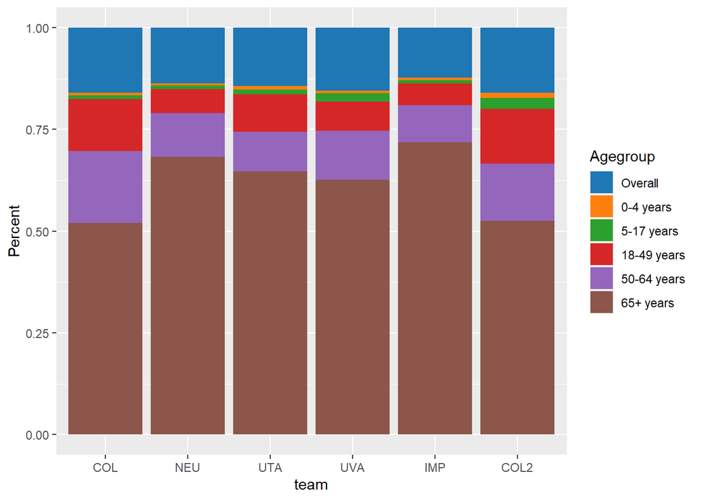

```r
ages <- read_ages(scn = scenario)
ggplot(ages, aes(fill=Agegroup, y=Cml, x=team)) +
  geom_bar(position="fill", stat="identity") +
  ylab("Percent")+
  scale_fill_d3()
```

```r
averted <- rbind(averted, data.frame(scenario = rep(scenario, nrow(table)),
                                     team = table$Team,
                                     reduction = table$`% Reduction in Burden (HP13)`))
averted_age <- rbind(averted_age,
                     data.frame(scenario = scenario,
                          team = ages$team[which(ages$Bin == "sm.mean")],
                          agegroup = ages$Agegroup[which(ages$Bin == "sm.mean")],
                          reduction = 100*(ages_1$Cml[which(ages_1$Bin == "sm.mean")] -
                                       ages$Cml[which(ages$Bin == "sm.mean")]) /
                            ages_1$Cml[which(ages_1$Bin == "sm.mean")]))
```

### HP18

SC3

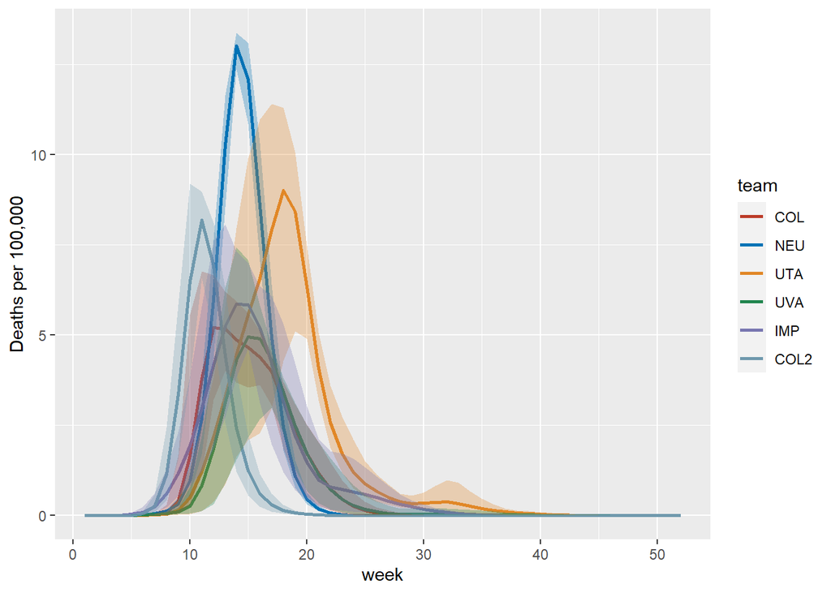

```r
scenario <- "HP18_"

long <- read_overall_mean(scn = scenario)

ggplot(data = long, aes(x = week, y = sm.mean, group = team)) +
  geom_line(aes(color = team), lwd = 1.0) +
  geom_ribbon(aes(ymin = sm.perc2p5, ymax = sm.perc97p5, fill = team), alpha = 0.3,
              show.legend = FALSE)+
  ylab("Deaths per 100,000") +
  scale_color_nejm() +
  scale_fill_nejm()
```

```r
table <- cml[which(cml$Bin == "sm.mean"),]
table <- table[,-3]

table$lower <-  cml$Cml[which(cml$Bin == "sm.perc2p5")]
table$upper <-  cml$Cml[which(cml$Bin == "sm.perc97p5")]
table$Team <- table$team
table$`Cum. Deaths per 100K` <- table$Cml
table$`95% CI` <- paste0("(", round(table$lower, 2), ", ", round(table$upper, 2), ")")

table$`Averted Deaths per 100K (HP13)` <- ifelse(table$Team %in% table1$Team, table1$`Cum. Deaths per 100K` - table$`Cum. Deaths per 100K`, NA)
table$`% Reduction in Burden (HP13)` <- ifelse(table$Team %in% table1$Team, 100 * (table1$`Cum. Deaths per 100K` - table$`Cum. Deaths per 100K`) / table1$`Cum. Deaths per 100K`, NA)

rownames(table) <- NULL

knitr::kable(table[5:9], digits = 2, caption = "HP18: Compared to HP13", align=rep('c', 4)) %>%
  kable_styling(bootstrap_options = c("striped", "hover"))
```

HP18: Compared to HP13

| Team | Cum. Deaths per 100K | 95% CI | Averted Deaths per 100K (HP13) | % Reduction in Burden (HP13) |
| --- | --- | --- | --- | --- |
| COL | 44.40 | (37.76, 51.03) | 0.99 | 2.17 |
| NEU | 63.34 | (63.24, 63.62) | 7.16 | 10.16 |
| UTA | 70.41 | (47.02, 87.7) | 8.60 | 10.88 |
| UVA | 35.78 | (28.27, 42.8) | 5.56 | 13.45 |
| IMP | 50.25 | (46.87, 54.63) | 4.85 | 8.81 |
| COL2 | 35.71 | (33.92, 37.66) | 3.44 | 8.78 |

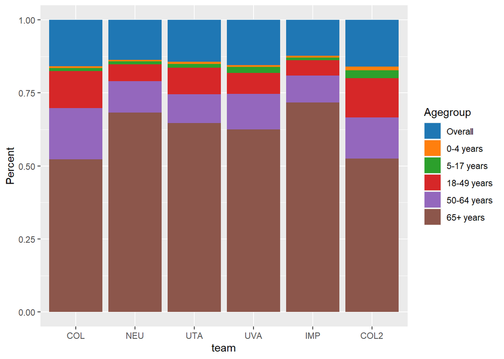

```r
ages <- read_ages(scn = scenario)
ggplot(ages, aes(fill=Agegroup, y=Cml, x=team)) +
  geom_bar(position="fill", stat="identity") +
  ylab("Percent")+
  scale_fill_d3()
```

```r
averted <- rbind(averted, data.frame(scenario = rep(scenario, nrow(table)),
                                     team = table$Team,
                                     reduction = table$`% Reduction in Burden (HP13)`))
averted_age <- rbind(averted_age,
                     data.frame(scenario = scenario,
                          team = ages$team[which(ages$Bin == "sm.mean")],
                          agegroup = ages$Agegroup[which(ages$Bin == "sm.mean")],
                          reduction = 100*(ages_1$Cml[which(ages_1$Bin == "sm.mean")] -
                                       ages$Cml[which(ages$Bin == "sm.mean")]) /
                            ages_1$Cml[which(ages_1$Bin == "sm.mean")]))
```

### HP19

SC4

Close on October 28, normal (VX2) vaccine availability reopening

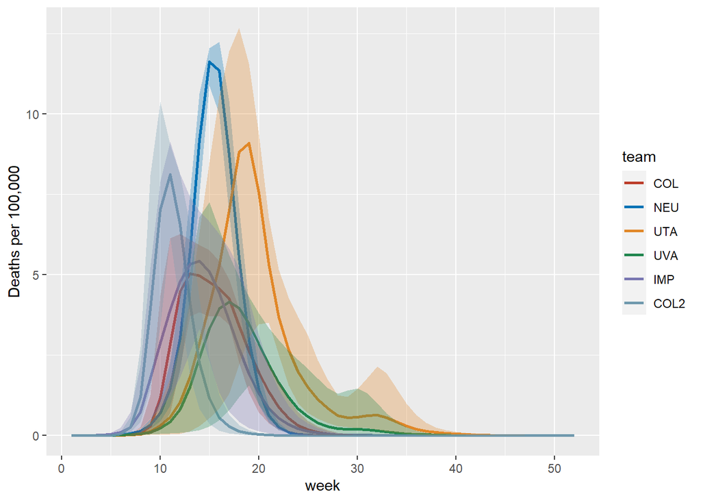

```r
scenario <- "HP19_"

long <- read_overall_mean(scn = scenario)

ggplot(data = long, aes(x = week, y = sm.mean, group = team)) +
  geom_line(aes(color = team), lwd = 1.0) +
  geom_ribbon(aes(ymin = sm.perc2p5, ymax = sm.perc97p5, fill = team), alpha = 0.3,
              show.legend = FALSE)+
  ylab("Deaths per 100,000") +
  scale_color_nejm() +
  scale_fill_nejm()
```

```r
table <- cml[which(cml$Bin == "sm.mean"),]
table <- table[,-3]

table$lower <-  cml$Cml[which(cml$Bin == "sm.perc2p5")]
table$upper <-  cml$Cml[which(cml$Bin == "sm.perc97p5")]
table$Team <- table$team
table$`Cum. Deaths per 100K` <- table$Cml
table$`95% CI` <- paste0("(", round(table$lower, 2), ", ", round(table$upper, 2), ")")

table$`Averted Deaths per 100K (HP13)` <- ifelse(table$Team %in% table1$Team, table1$`Cum. Deaths per 100K` - table$`Cum. Deaths per 100K`, NA)
table$`% Reduction in Burden (HP13)` <- ifelse(table$Team %in% table1$Team, 100 * (table1$`Cum. Deaths per 100K` - table$`Cum. Deaths per 100K`) / table1$`Cum. Deaths per 100K`, NA)

rownames(table) <- NULL

knitr::kable(table[5:9], digits = 2, caption = "HP19: Compared to HP13", align=rep('c', 4)) %>%
  kable_styling(bootstrap_options = c("striped", "hover"))
```

HP19: Compared to HP13

| Team | Cum. Deaths per 100K | 95% CI | Averted Deaths per 100K (HP13) | % Reduction in Burden (HP13) |
| --- | --- | --- | --- | --- |
| COL | 44.04 | (37.47, 50.64) | 1.35 | 2.96 |
| NEU | 63.46 | (63.36, 63.74) | 7.04 | 9.98 |
| UTA | 70.77 | (46.56, 88.93) | 8.24 | 10.43 |
| UVA | 35.90 | (30.2, 42.68) | 5.44 | 13.16 |
| IMP | 46.68 | (43.61, 51.84) | 8.42 | 15.27 |
| COL2 | 35.80 | (33.96, 37.78) | 3.35 | 8.56 |

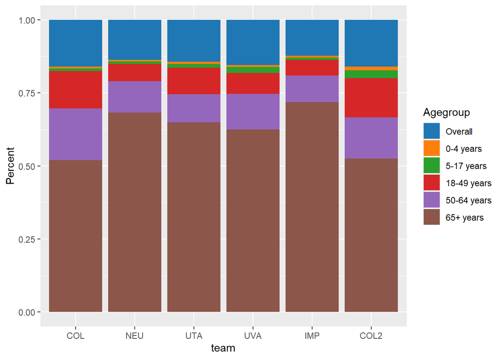

```r
ages <- read_ages(scn = scenario)
ggplot(ages, aes(fill=Agegroup, y=Cml, x=team)) +
  geom_bar(position="fill", stat="identity") +
  ylab("Percent")+
  scale_fill_d3()
```

```r
averted <- rbind(averted, data.frame(scenario = rep(scenario, nrow(table)),
                                     team = table$Team,
                                     reduction = table$`% Reduction in Burden (HP13)`))
averted_age <- rbind(averted_age,
                     data.frame(scenario = scenario,
                          team = ages$team[which(ages$Bin == "sm.mean")],
                          agegroup = ages$Agegroup[which(ages$Bin == "sm.mean")],
                          reduction = 100*(ages_1$Cml[which(ages_1$Bin == "sm.mean")] -
                                       ages$Cml[which(ages$Bin == "sm.mean")]) /
                            ages_1$Cml[which(ages_1$Bin == "sm.mean")]))
```

### HP20

AV

Antivirals

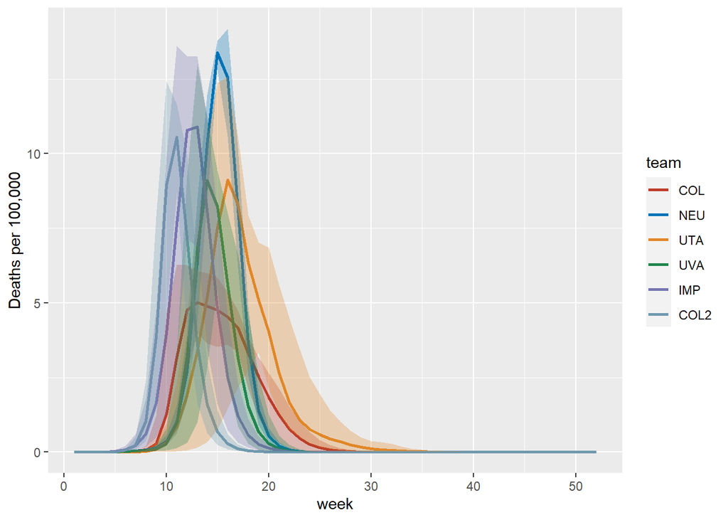

```r
scenario <- "HP20_"

long <- read_overall_mean(scn = scenario)

ggplot(data = long, aes(x = week, y = sm.mean, group = team)) +
  geom_line(aes(color = team), lwd = 1.0) +
  geom_ribbon(aes(ymin = sm.perc2p5, ymax = sm.perc97p5, fill = team), alpha = 0.3,
              show.legend = FALSE)+
  ylab("Deaths per 100,000") +
  scale_color_nejm() +
  scale_fill_nejm()
```

```r
table <- cml[which(cml$Bin == "sm.mean"),]
table <- table[,-3]

table$lower <-  cml$Cml[which(cml$Bin == "sm.perc2p5")]
table$upper <-  cml$Cml[which(cml$Bin == "sm.perc97p5")]
table$Team <- table$team
table$`Cum. Deaths per 100K` <- table$Cml
table$`95% CI` <- paste0("(", round(table$lower, 2), ", ", round(table$upper, 2), ")")

table$`Averted Deaths per 100K (HP13)` <- ifelse(table$Team %in% table1$Team, table1$`Cum. Deaths per 100K` - table$`Cum. Deaths per 100K`, NA)
table$`% Reduction in Burden (HP13)` <- ifelse(table$Team %in% table1$Team, 100 * (table1$`Cum. Deaths per 100K` - table$`Cum. Deaths per 100K`) / table1$`Cum. Deaths per 100K`, NA)

rownames(table) <- NULL

knitr::kable(table[5:9], digits = 2, caption = "HP20: Compared to HP13", align=rep('c', 4)) %>%
  kable_styling(bootstrap_options = c("striped", "hover"))
```

HP20: Compared to HP13

| Team | Cum. Deaths per 100K | 95% CI | Averted Deaths per 100K (HP13) | % Reduction in Burden (HP13) |
| --- | --- | --- | --- | --- |
| COL | 43.67 | (37.13, 50.2) | 1.72 | 3.80 |
| NEU | 61.02 | (60.99, 61.1) | 9.48 | 13.45 |
| UTA | 60.52 | (40.33, 73.6) | 18.49 | 23.41 |
| UVA | 40.32 | (33.62, 46.17) | 1.02 | 2.46 |
| IMP | 53.67 | (49.49, 59.41) | 1.43 | 2.60 |
| COL2 | 38.29 | (36.51, 40.23) | 0.86 | 2.20 |

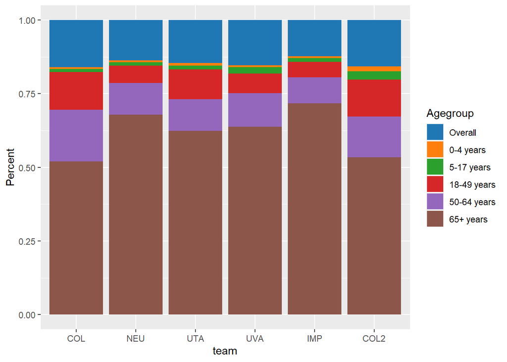

```r
ages <- read_ages(scn = scenario)
ggplot(ages, aes(fill=Agegroup, y=Cml, x=team)) +
  geom_bar(position="fill", stat="identity") +
  ylab("Percent")+
  scale_fill_d3()
```

```r
averted <- rbind(averted, data.frame(scenario = rep(scenario, nrow(table)),
                                     team = table$Team,
                                     reduction = table$`% Reduction in Burden (HP13)`))
averted_age <- rbind(averted_age,
                     data.frame(scenario = scenario,
                          team = ages$team[which(ages$Bin == "sm.mean")],
                          agegroup = ages$Agegroup[which(ages$Bin == "sm.mean")],
                          reduction = 100*(ages_1$Cml[which(ages_1$Bin == "sm.mean")] -
                                       ages$Cml[which(ages$Bin == "sm.mean")]) /
                            ages_1$Cml[which(ages_1$Bin == "sm.mean")]))
```

### HP21

VX1 & SC1 & AV

- “Early”: Vaccine available 100 days after September 1
- Weekly Symptomatic Prevalence > 1% trigger, early (VX1) vaccine availability reopening
- Antivirals

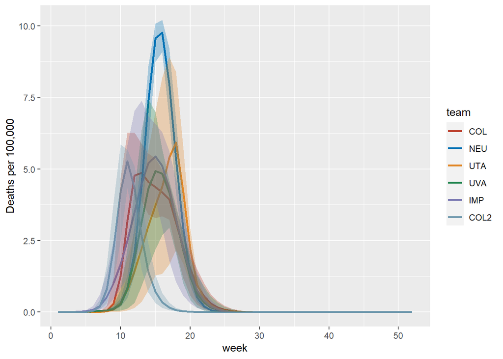

```r
scenario <- "HP21_"

long <- read_overall_mean(scn = scenario)

ggplot(data = long, aes(x = week, y = sm.mean, group = team)) +
  geom_line(aes(color = team), lwd = 1.0) +
  geom_ribbon(aes(ymin = sm.perc2p5, ymax = sm.perc97p5, fill = team), alpha = 0.3,
              show.legend = FALSE)+
  ylab("Deaths per 100,000") +
  scale_color_nejm() +
  scale_fill_nejm()
```

```r
table <- cml[which(cml$Bin == "sm.mean"),]
table <- table[,-3]

table$lower <-  cml$Cml[which(cml$Bin == "sm.perc2p5")]
table$upper <-  cml$Cml[which(cml$Bin == "sm.perc97p5")]
table$Team <- table$team
table$`Cum. Deaths per 100K` <- table$Cml
table$`95% CI` <- paste0("(", round(table$lower, 2), ", ", round(table$upper, 2), ")")

table$`Averted Deaths per 100K (HP13)` <- ifelse(table$Team %in% table1$Team, table1$`Cum. Deaths per 100K` - table$`Cum. Deaths per 100K`, NA)
table$`% Reduction in Burden (HP13)` <- ifelse(table$Team %in% table1$Team, 100 * (table1$`Cum. Deaths per 100K` - table$`Cum. Deaths per 100K`) / table1$`Cum. Deaths per 100K`, NA)

rownames(table) <- NULL

knitr::kable(table[5:9], digits = 2, caption = "HP21: Compared to HP13", align=rep('c', 4)) %>%
  kable_styling(bootstrap_options = c("striped", "hover"))
```

HP21: Compared to HP13

| Team | Cum. Deaths per 100K | 95% CI | Averted Deaths per 100K (HP13) | % Reduction in Burden (HP13) |
| --- | --- | --- | --- | --- |
| COL | 40.55 | (33, 48.23) | 4.84 | 10.66 |
| NEU | 52.99 | (52.96, 53.08) | 17.51 | 24.84 |
| UTA | 35.66 | (12.7, 56.57) | 43.35 | 54.86 |
| UVA | 32.59 | (21.8, 41.16) | 8.75 | 21.17 |
| IMP | 42.47 | (36.8, 48.77) | 12.63 | 22.91 |
| COL2 | 22.49 | (21.78, 23.25) | 16.66 | 42.56 |

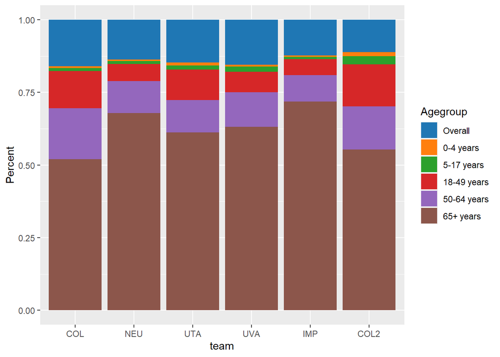

```r
ages <- read_ages(scn = scenario)
ggplot(ages, aes(fill=Agegroup, y=Cml, x=team)) +
  geom_bar(position="fill", stat="identity") +
  ylab("Percent")+
  scale_fill_d3()
```

```r
averted <- rbind(averted, data.frame(scenario = rep(scenario, nrow(table)),
                                     team = table$Team,
                                     reduction = table$`% Reduction in Burden (HP13)`))
averted_age <- rbind(averted_age,
                     data.frame(scenario = scenario,
                          team = ages$team[which(ages$Bin == "sm.mean")],
                          agegroup = ages$Agegroup[which(ages$Bin == "sm.mean")],
                          reduction = 100*(ages_1$Cml[which(ages_1$Bin == "sm.mean")] -
                                       ages$Cml[which(ages$Bin == "sm.mean")]) /
                            ages_1$Cml[which(ages_1$Bin == "sm.mean")]))
```

### HP22

VX1 & SC2 & AV

- “Early”: Vaccine available 100 days after September 1
- Close on October 28, early (VX1) vaccine availability reopening
- Antivirals

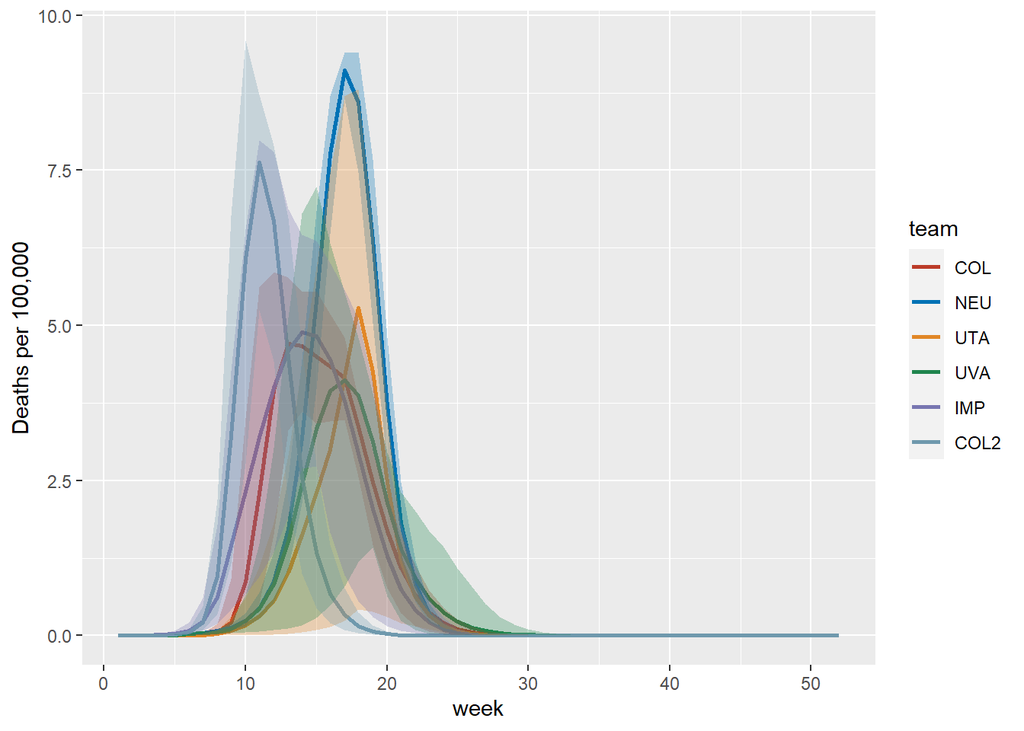

```r
scenario <- "HP22_"

long <- read_overall_mean(scn = scenario)

ggplot(data = long, aes(x = week, y = sm.mean, group = team)) +
  geom_line(aes(color = team), lwd = 1.0) +
  geom_ribbon(aes(ymin = sm.perc2p5, ymax = sm.perc97p5, fill = team), alpha = 0.3,
              show.legend = FALSE)+
  ylab("Deaths per 100,000") +
  scale_color_nejm() +
  scale_fill_nejm()
```

```r
table <- cml[which(cml$Bin == "sm.mean"),]
table <- table[,-3]

table$lower <-  cml$Cml[which(cml$Bin == "sm.perc2p5")]
table$upper <-  cml$Cml[which(cml$Bin == "sm.perc97p5")]
table$Team <- table$team
table$`Cum. Deaths per 100K` <- table$Cml
table$`95% CI` <- paste0("(", round(table$lower, 2), ", ", round(table$upper, 2), ")")

table$`Averted Deaths per 100K (HP13)` <- ifelse(table$Team %in% table1$Team, table1$`Cum. Deaths per 100K` - table$`Cum. Deaths per 100K`, NA)
table$`% Reduction in Burden (HP13)` <- ifelse(table$Team %in% table1$Team, 100 * (table1$`Cum. Deaths per 100K` - table$`Cum. Deaths per 100K`) / table1$`Cum. Deaths per 100K`, NA)

rownames(table) <- NULL

knitr::kable(table[5:9], digits = 2, caption = "HP22: Compared to HP13", align=rep('c', 4)) %>%
  kable_styling(bootstrap_options = c("striped", "hover"))
```

HP22: Compared to HP13

| Team | Cum. Deaths per 100K | 95% CI | Averted Deaths per 100K (HP13) | % Reduction in Burden (HP13) |
| --- | --- | --- | --- | --- |
| COL | 39.84 | (32.34, 47.66) | 5.55 | 12.23 |
| NEU | 50.83 | (50.57, 51.55) | 19.66 | 27.89 |
| UTA | 27.69 | (2.21, 54.1) | 51.32 | 64.95 |
| UVA | 30.00 | (16.16, 40.77) | 11.34 | 27.44 |
| IMP | 42.29 | (36.59, 48.75) | 12.81 | 23.25 |
| COL2 | 34.50 | (32.67, 36.51) | 4.65 | 11.88 |

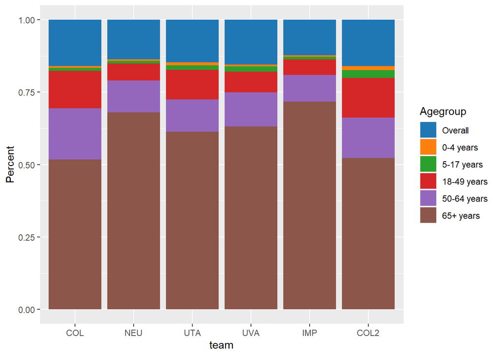

```r
ages <- read_ages(scn = scenario)
ggplot(ages, aes(fill=Agegroup, y=Cml, x=team)) +
  geom_bar(position="fill", stat="identity") +
  ylab("Percent")+
  scale_fill_d3()
```

```r
averted <- rbind(averted, data.frame(scenario = rep(scenario, nrow(table)),
                                     team = table$Team,
                                     reduction = table$`% Reduction in Burden (HP13)`))
averted_age <- rbind(averted_age,
                     data.frame(scenario = scenario,
                          team = ages$team[which(ages$Bin == "sm.mean")],
                          agegroup = ages$Agegroup[which(ages$Bin == "sm.mean")],
                          reduction = 100*(ages_1$Cml[which(ages_1$Bin == "sm.mean")] -
                                       ages$Cml[which(ages$Bin == "sm.mean")]) /
                            ages_1$Cml[which(ages_1$Bin == "sm.mean")]))
```

### HP23

VX2 & SC3 & AV

- “Normal”: Vaccine available 150 days after September 1
- Weekly Symptomatic Prevalence > 1% trigger, normal (VX2) vaccine availability reopening
- Antivirals

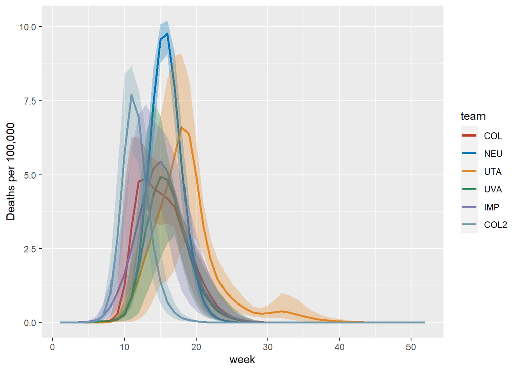

```r
scenario <- "HP23_"

long <- read_overall_mean(scn = scenario)

ggplot(data = long, aes(x = week, y = sm.mean, group = team)) +
  geom_line(aes(color = team), lwd = 1.0) +
  geom_ribbon(aes(ymin = sm.perc2p5, ymax = sm.perc97p5, fill = team), alpha = 0.3,
              show.legend = FALSE)+
  ylab("Deaths per 100,000") +
  scale_color_nejm() +
  scale_fill_nejm()
```

```r
table <- cml[which(cml$Bin == "sm.mean"),]
table <- table[,-3]

table$lower <-  cml$Cml[which(cml$Bin == "sm.perc2p5")]
table$upper <-  cml$Cml[which(cml$Bin == "sm.perc97p5")]
table$Team <- table$team
table$`Cum. Deaths per 100K` <- table$Cml
table$`95% CI` <- paste0("(", round(table$lower, 2), ", ", round(table$upper, 2), ")")

table$`Averted Deaths per 100K (HP13)` <- ifelse(table$Team %in% table1$Team, table1$`Cum. Deaths per 100K` - table$`Cum. Deaths per 100K`, NA)
table$`% Reduction in Burden (HP13)` <- ifelse(table$Team %in% table1$Team, 100 * (table1$`Cum. Deaths per 100K` - table$`Cum. Deaths per 100K`) / table1$`Cum. Deaths per 100K`, NA)

rownames(table) <- NULL

knitr::kable(table[5:9], digits = 2, caption = "HP23: Compared to HP13", align=rep('c', 4)) %>%
  kable_styling(bootstrap_options = c("striped", "hover"))
```

HP23: Compared to HP13

| Team | Cum. Deaths per 100K | 95% CI | Averted Deaths per 100K (HP13) | % Reduction in Burden (HP13) |
| --- | --- | --- | --- | --- |
| COL | 42.61 | (36.29, 49.16) | 2.78 | 6.12 |
| NEU | 53.85 | (53.77, 54.07) | 16.65 | 23.62 |
| UTA | 53.16 | (30.22, 68.84) | 25.85 | 32.72 |
| UVA | 34.47 | (25.64, 41.69) | 6.87 | 16.62 |
| IMP | 44.83 | (40.9, 50.1) | 10.27 | 18.64 |
| COL2 | 34.50 | (32.71, 36.48) | 4.65 | 11.88 |

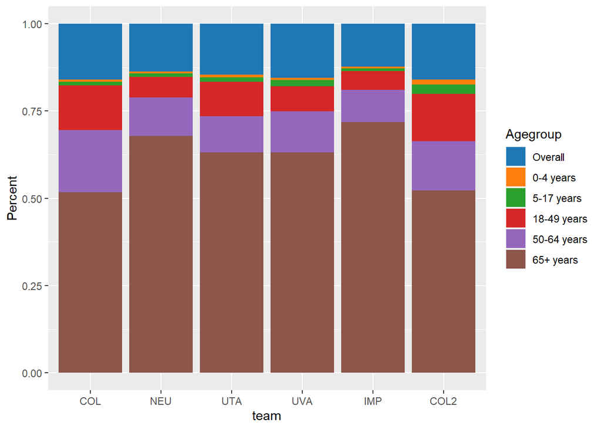

```r
ages <- read_ages(scn = scenario)
ggplot(ages, aes(fill=Agegroup, y=Cml, x=team)) +
  geom_bar(position="fill", stat="identity") +
  ylab("Percent")+
  scale_fill_d3()
```

```r
averted <- rbind(averted, data.frame(scenario = rep(scenario, nrow(table)),
                                     team = table$Team,
                                     reduction = table$`% Reduction in Burden (HP13)`))
averted_age <- rbind(averted_age,
                     data.frame(scenario = scenario,
                          team = ages$team[which(ages$Bin == "sm.mean")],
                          agegroup = ages$Agegroup[which(ages$Bin == "sm.mean")],
                          reduction = 100*(ages_1$Cml[which(ages_1$Bin == "sm.mean")] -
                                       ages$Cml[which(ages$Bin == "sm.mean")]) /
                            ages_1$Cml[which(ages_1$Bin == "sm.mean")]))
```

### HP24

VX2 & SC4 & AV

- “Normal”: Vaccine available 150 days after September 1
- Close on October 28, normal (VX2) vaccine availability reopening
- Antivirals

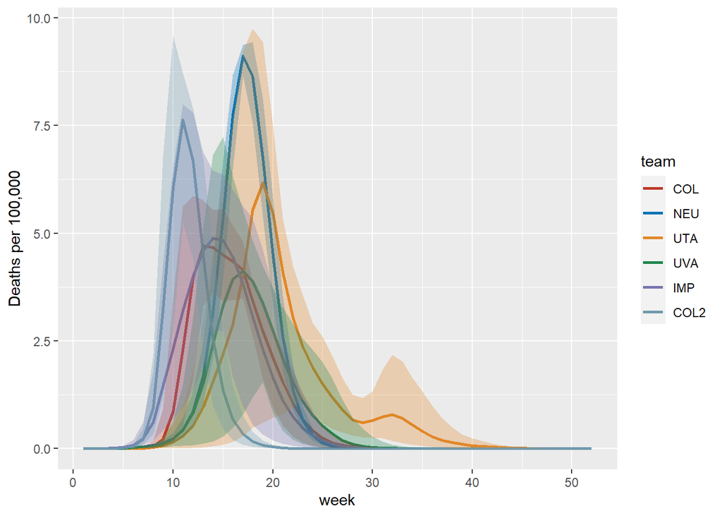

```r
scenario <- "HP24_"

long <- read_overall_mean(scn = scenario)

ggplot(data = long, aes(x = week, y = sm.mean, group = team)) +
  geom_line(aes(color = team), lwd = 1.0) +
  geom_ribbon(aes(ymin = sm.perc2p5, ymax = sm.perc97p5, fill = team), alpha = 0.3,
              show.legend = FALSE)+
  ylab("Deaths per 100,000") +
  scale_color_nejm() +
  scale_fill_nejm()
```

```r
table <- cml[which(cml$Bin == "sm.mean"),]
table <- table[,-3]

table$lower <-  cml$Cml[which(cml$Bin == "sm.perc2p5")]
table$upper <-  cml$Cml[which(cml$Bin == "sm.perc97p5")]
table$Team <- table$team
table$`Cum. Deaths per 100K` <- table$Cml
table$`95% CI` <- paste0("(", round(table$lower, 2), ", ", round(table$upper, 2), ")")

table$`Averted Deaths per 100K (HP13)` <- ifelse(table$Team %in% table1$Team, table1$`Cum. Deaths per 100K` - table$`Cum. Deaths per 100K`, NA)
table$`% Reduction in Burden (HP13)` <- ifelse(table$Team %in% table1$Team, 100 * (table1$`Cum. Deaths per 100K` - table$`Cum. Deaths per 100K`) / table1$`Cum. Deaths per 100K`, NA)

rownames(table) <- NULL

knitr::kable(table[5:9], digits = 2, caption = "HP24: Compared to HP13", align=rep('c', 4)) %>%
  kable_styling(bootstrap_options = c("striped", "hover"))
```

HP24: Compared to HP13

| Team | Cum. Deaths per 100K | 95% CI | Averted Deaths per 100K (HP13) | % Reduction in Burden (HP13) |
| --- | --- | --- | --- | --- |
| COL | 42.25 | (35.99, 48.81) | 3.14 | 6.91 |
| NEU | 53.89 | (53.82, 54.1) | 16.61 | 23.56 |
| UTA | 50.95 | (26.21, 69.47) | 28.06 | 35.51 |
| UVA | 33.86 | (23.09, 41.56) | 7.48 | 18.09 |
| IMP | 44.57 | (41.47, 49.53) | 10.53 | 19.11 |
| COL2 | 34.55 | (32.71, 36.58) | 4.59 | 11.74 |

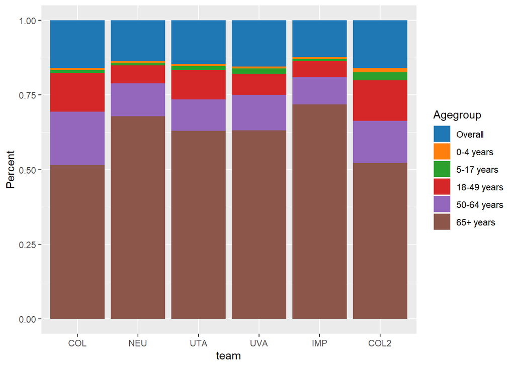

```r
ages <- read_ages(scn = scenario)
ggplot(ages, aes(fill=Agegroup, y=Cml, x=team)) +
  geom_bar(position="fill", stat="identity") +
  ylab("Percent")+
  scale_fill_d3()
```

```r
averted <- rbind(averted, data.frame(scenario = rep(scenario, nrow(table)),
                                     team = table$Team,
                                     reduction = table$`% Reduction in Burden (HP13)`))
averted_age <- rbind(averted_age,
                     data.frame(scenario = scenario,
                          team = ages$team[which(ages$Bin == "sm.mean")],
                          agegroup = ages$Agegroup[which(ages$Bin == "sm.mean")],
                          reduction = 100*(ages_1$Cml[which(ages_1$Bin == "sm.mean")] -
                                       ages$Cml[which(ages$Bin == "sm.mean")]) /
                            ages_1$Cml[which(ages_1$Bin == "sm.mean")]))
write.csv(averted, "Deaths_EPI2.csv")
write.csv(averted_age, "Deaths_age_EPI2.csv")
```